# Lognormal race with unknown winner

Bruno Nicenboim

6/27/2019

```r
set.seed(42)
library(ggplot2)
library(tidyr)
library(dplyr)
library(rstan)
rstan_options(auto_write = TRUE)
options(mc.cores = 3)
```

I’m here trying to simulate the outcome of two processes, one is the time-out (`to`) that goes down according to the practice law, and another one `proc` that depends on a predictor `X`. The two processes follow lognormal distributions with the same variance, and the fastest one is the observed one. Importantly, I can’t know directly which is the one that finished first in each trial.

```r
N <- 5000
X <- rnorm(N)
Int_to <- log(1000) ##log(1000) = 6.9
Int_proc <- 6
r <- .0005
#effect of something:
mu_proc <- Int_proc + X *.1
#practice:
mu_to <- Int_to + -r*(1:N)
sigma <- .5
proc <- rlnorm(N,mu_proc,sigma)
to <- rlnorm(N,mu_to,sigma)
data <- tibble(trial=1:N,X,
               proc=proc,
               to=to,
               RT = pmin(proc, to),
               ## IRL, I don't know which one actually wins:
               winner_proc = proc< to)
```

It will look like this (the crosses are the observations):

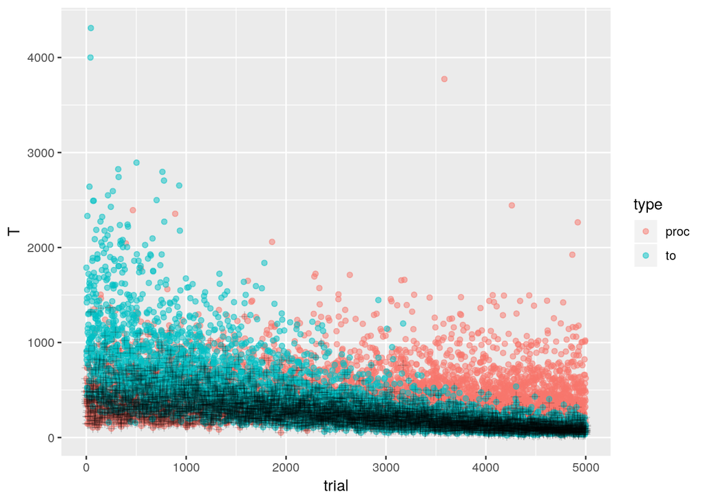

```r
data %>% gather(key="type",value="T", proc, to) %>%
    ggplot( aes(x=trial, y=T, color = type)) + geom_point(alpha=.5) +
    geom_point(aes(y=RT), size=2, color= "black", alpha=.1, shape =3)
```

This is the proportion of times `proc` won and was observed:

```r
mean(proc < to)
```

```
## [1] 0.3792
```

```r
mean(data$winner_proc)
```

```
## [1] 0.3792
```

Because these are two lognormal distributions, I can also calculate the proportions of the mixture like this, for every trial:

```r
plnorm(1, mu_proc - mu_to, sqrt(2) * sigma) %>% head()
```

```
## [1] 0.8619605 0.9134336 0.8907047 0.8832578 0.8893450 0.9022580
```

And on average:

```r
plnorm(1, mu_proc - mu_to, sqrt(2) * sigma) %>% mean()
```

```
## [1] 0.3760105
```

## Stan model of the race (a lognormal race model with an unknown winner)

I try to fit this in stan with quite informative priors:

```
functions {
  // Stable approximation of the cdf that works better close to 0 and 1
  real lognormal_approx_cdf(real x, real mu, real sigma){
    real x_n = (log(x)-mu)/sigma;
    return inv_logit(0.07056 * x_n^3 + 1.5976* x_n);
  }
}
data {
  int N;
  vector<lower=0>[N] RT;
  vector[N] X;
  vector[N] trial;
}
parameters {
 real<lower=0> sigma;
  real Int_proc;
  real<lower= Int_proc> Int_to;
  real slope;
  real<lower=0> r;
}
transformed parameters{
  vector[N] mu_proc= Int_proc + X* slope;
  vector[N] mu_to = Int_to  - r* (trial/1000);
  vector[N] P_proc;
    //  given:
    // X ~ lognormal(mu_proc, sigma)
    // Y ~ lognormal(mu_to, sigma)
    // then:
    // X/Y ~ lognormal(mu_proc - mu_to, sqrt(2.0)* sigma)
    // X/Y < 1 => X was faster and was selected
    // P(X < Y) = lognormal_cdf(1, mu_proc - mu_to, sqrt(2.0)* sigma)
  for(n in 1:N)
     P_proc[n] = lognormal_approx_cdf(1.0,  mu_proc[n] - mu_to[n], sqrt(2.0)*sigma);
  //P_proc[n] = lognormal_cdf(1.0,  mu_proc[n] - mu_to[n], sqrt(2.0)*sigma);
}
model {
  // Quite informative priors:
  Int_proc~ normal(6,.1);
  Int_to ~ normal(log(1000),.1);
  slope ~ normal(.1,.3);
  r ~ lognormal(log(.5),.2);
  sigma ~ normal(.5,.5);
  // Likelihood:
  for (n in 1:N){
    target += log_mix(P_proc[n],  lognormal_lpdf(RT[n]|mu_proc[n],sigma),
                      lognormal_lpdf(RT[n]|mu_to[n],sigma)
                      );
  }
}
generated quantities {
  real P_proc_avg = mean(P_proc);
  real RT_proc[N];
  real RT_to[N];
  real RT_gen[N];
  int winner_proc_gen[N];
  for(n in 1:N){
  RT_proc[n] = lognormal_rng(mu_proc[n],sigma);
  RT_to[n] = lognormal_rng(mu_to[n],sigma);
  // Generate fake data
  if(RT_proc[n] < RT_to[n]){
      winner_proc_gen[n] = 1;
      RT_gen[n] = RT_proc[n];
    } else {
      winner_proc_gen[n] = 0;
      RT_gen[n] = RT_to[n];
    }
  }
}
```

```r
data_simple <- as.list(data) %>% c(N=nrow(data))
out_simple <- stan("race_proc.stan", data=data_simple, chains =6,iter=1000)
```

It doesn’t work:

```r
print(out_simple, pars= c("Int_proc","Int_to","slope", "r", "sigma", "P_proc_avg"), probs = c(0.025,  0.50,  0.975))
```

```
## Inference for Stan model: race_proc.
## 6 chains, each with iter=1000; warmup=500; thin=1;
## post-warmup draws per chain=500, total post-warmup draws=3000.
##
##            mean se_mean   sd 2.5%  50% 97.5% n_eff  Rhat
## Int_proc   5.74    0.09 0.16 5.38 5.80  5.83     3 13.75
## Int_to     6.68    0.32 0.55 6.39 6.44  7.98     3 16.68
## slope      0.07    0.01 0.02 0.02 0.07  0.10     4  1.82
## r          0.35    0.06 0.11 0.10 0.40  0.42     3 13.68
## sigma      0.46    0.05 0.08 0.42 0.43  0.65     3 17.13
## P_proc_avg 0.44    0.14 0.25 0.32 0.34  0.99     3 34.90
##
## Samples were drawn using NUTS(diag_e) at Thu Jun 27 16:07:01 2019.
## For each parameter, n_eff is a crude measure of effective sample size,
## and Rhat is the potential scale reduction factor on split chains (at
## convergence, Rhat=1).
```

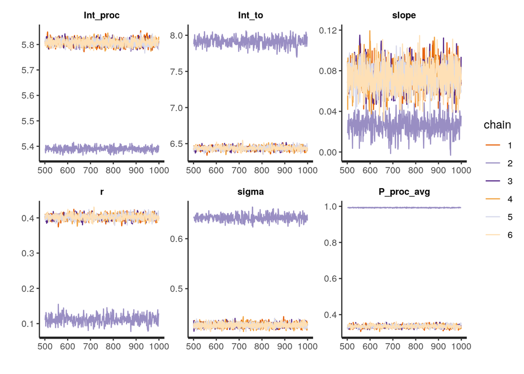

```r
traceplot(out_simple, pars= c("Int_proc","Int_to","slope", "r", "sigma", "P_proc_avg"))
```

These are the summaries of the individual chains, they are actually too precise:

```r
summary(out_simple,  pars= c("Int_proc","Int_to","slope", "r", "sigma", "P_proc_avg"), probs = c(0.025,  0.50,  0.975))
```

```
## $summary
##                  mean    se_mean         sd       2.5%        50%
## Int_proc   5.73799688 0.08982981 0.15606441 5.38092551 5.80443967
## Int_to     6.68244958 0.31757873 0.55131496 6.38867866 6.44160616
## slope      0.06594994 0.01056367 0.02185362 0.01674448 0.07025824
## r          0.35378137 0.06262371 0.10880573 0.09903862 0.40050442
## sigma      0.46279271 0.04623331 0.08024907 0.41907109 0.42797687
## P_proc_avg 0.44492992 0.14135251 0.24505221 0.32018931 0.33747496
##                 97.5%    n_eff      Rhat
## Int_proc   5.83093667 3.018331 13.748666
## Int_to     7.97849311 3.013677 16.679689
## slope      0.09803918 4.279734  1.817898
## r          0.41624029 3.018742 13.677741
## sigma      0.64860785 3.012798 17.132210
## P_proc_avg 0.99393059 3.005455 34.897082
##
## $c_summary
## , , chains = chain:1
##
##             stats
## parameter          mean          sd       2.5%        50%     97.5%
##   Int_proc   5.80795225 0.013082362 5.78239410 5.80778009 5.8360590
##   Int_to     6.43666946 0.026358783 6.38194377 6.43694285 6.4891398
##   slope      0.07444276 0.013048573 0.05034508 0.07389443 0.1011839
##   r          0.40236709 0.007548291 0.38629613 0.40252334 0.4162219
##   sigma      0.42703660 0.004461521 0.41882093 0.42677545 0.4363043
##   P_proc_avg 0.33530710 0.008565246 0.31785774 0.33540594 0.3517382
##
## , , chains = chain:2
##
##             stats
## parameter          mean          sd        2.5%        50%      97.5%
##   Int_proc   5.39009434 0.009318823 5.370617514 5.39021896 5.40814786
##   Int_to     7.91260275 0.062274018 7.785307928 7.91302480 8.02795541
##   slope      0.02572521 0.009025831 0.007278738 0.02598826 0.04173536
##   r          0.11123656 0.012376617 0.088554029 0.11059339 0.13786284
##   sigma      0.64187184 0.006677239 0.629745616 0.64206365 0.65563508
##   P_proc_avg 0.99254533 0.001332356 0.989757926 0.99268686 0.99485651
##
## , , chains = chain:3
```

[output cut: 27 more lines]

```
##   slope      0.07318538 0.011845760 0.05082766 0.07324673 0.09518139
##   r          0.40249694 0.007476425 0.38851318 0.40232549 0.41718309
##   sigma      0.42700332 0.004492388 0.41899430 0.42683181 0.43576673
##   P_proc_avg 0.33578221 0.008308493 0.32026993 0.33568762 0.35255529
##
## , , chains = chain:6
##
##             stats
## parameter          mean          sd       2.5%        50%     97.5%
##   Int_proc   5.80759500 0.011661775 5.78468420 5.80754163 5.8288839
##   Int_to     6.43678167 0.024700618 6.39187236 6.43560775 6.4864622
##   slope      0.07332845 0.014225131 0.04609971 0.07315476 0.1000853
##   r          0.40241792 0.006984725 0.38916517 0.40215185 0.4164824
##   sigma      0.42661485 0.004353502 0.41814542 0.42646838 0.4353758
##   P_proc_avg 0.33538756 0.007656575 0.32097457 0.33505496 0.3512640
```

## Stan model of a lognormal race model, assuming I know the winner (which I don’t)

If I know which process is the fastest one, this is simply a lognormal race model, and it’s quite easy to fit:

```
functions {
  // Stable approximation of the cdf that works better close to 0 and 1
  real lognormal_approx_cdf(real x, real mu, real sigma){
    real x_n = (log(x)-mu)/sigma;
    return inv_logit(0.07056 * x_n^3 + 1.5976* x_n);
  }
}
data {
  int N;
  vector<lower=0>[N] RT;
  vector[N] X;
  vector[N] trial;
}
parameters {
 real<lower=0> sigma;
  real Int_proc;
  real<lower= Int_proc> Int_to;
  real slope;
  real<lower=0> r;
}
transformed parameters{
  vector[N] mu_proc= Int_proc + X* slope;
  vector[N] mu_to = Int_to  - r* (trial/1000);
  vector[N] P_proc;
    //  given:
    // X ~ lognormal(mu_proc, sigma)
    // Y ~ lognormal(mu_to, sigma)
    // then:
    // X/Y ~ lognormal(mu_proc - mu_to, sqrt(2.0)* sigma)
    // X/Y < 1 => X was faster and was selected
    // P(X < Y) = lognormal_cdf(1, mu_proc - mu_to, sqrt(2.0)* sigma)
  for(n in 1:N)
     P_proc[n] = lognormal_approx_cdf(1.0,  mu_proc[n] - mu_to[n], sqrt(2.0)*sigma);
  //P_proc[n] = lognormal_cdf(1.0,  mu_proc[n] - mu_to[n], sqrt(2.0)*sigma);
}
model {
  // Quite informative priors:
  Int_proc~ normal(6,1);
  Int_to ~ normal(log(1000),1);
  slope ~ normal(.1,.3);
  r ~ lognormal(log(.5),.2);
  sigma ~ normal(.5,.5);
  // Likelihood:
  for (n in 1:N){
    if(winner_proc[n]){
      target +=  lognormal_lpdf(RT[n]|mu_proc[n],sigma);
      target +=lognormal_lccdf(RT[n]|mu_to[n],sigma);
    } else {
      target += lognormal_lpdf(RT[n]|mu_to[n],sigma);
      target +=lognormal_lccdf(RT[n]|mu_proc[n],sigma);
    }
  }
}
generated quantities {
  real P_proc_avg = mean(P_proc);
  real RT_proc[N];
  real RT_to[N];
  real RT_gen[N];
  int winner_proc_gen[N];
  for(n in 1:N){
  RT_proc[n] = lognormal_rng(mu_proc[n],sigma);
  RT_to[n] = lognormal_rng(mu_to[n],sigma);
  // Generate fake data
  if(RT_proc[n] < RT_to[n]){
      winner_proc_gen[n] = 1;
      RT_gen[n] = RT_proc[n];
    } else {
      winner_proc_gen[n] = 0;
      RT_gen[n] = RT_to[n];
    }
  }
}
```

```r
data_simple <- as.list(data) %>% c(N=nrow(data))
out_simple_known <- stan("race_proc_known.stan", data=data_simple, chains =6,iter=1000)
```

It works, but I’m using data that I shouldn’t have:

```r
print(out_simple_known, pars= c("Int_proc","Int_to","slope", "r", "sigma", "P_proc_avg"), probs = c(0.025,  0.50,  0.975))
```

```
## Inference for Stan model: race_proc_known.
## 6 chains, each with iter=1000; warmup=500; thin=1;
## post-warmup draws per chain=500, total post-warmup draws=3000.
##
##            mean se_mean   sd 2.5%  50% 97.5% n_eff Rhat
## Int_proc   6.00       0 0.01 5.98 6.00  6.02  2807    1
## Int_to     6.91       0 0.02 6.87 6.91  6.95  2221    1
## slope      0.09       0 0.01 0.07 0.09  0.11  3249    1
## r          0.50       0 0.01 0.49 0.50  0.51  2307    1
## sigma      0.50       0 0.00 0.49 0.50  0.51  2729    1
## P_proc_avg 0.38       0 0.00 0.37 0.38  0.38  2464    1
##
## Samples were drawn using NUTS(diag_e) at Thu Jun 27 16:18:42 2019.
## For each parameter, n_eff is a crude measure of effective sample size,
## and Rhat is the potential scale reduction factor on split chains (at
## convergence, Rhat=1).
```